# Midterm 2

## Question 3

### Tim Demetriades

11/20/2021

#### Collect the stock price for Tesla (NASDAQ: TSLA) for the past 30 days.

#### (a) Plot the data (date vs. stock price)

```python
# import modules
from datetime import datetime
import yfinance as yf
import matplotlib.pyplot as plt
import numpy as np
```

```python
# set dates
start_date = datetime(2021, 10, 16)
end_date = datetime(2021, 11, 16)
```

```python
# get stock prices
prices_df = yf.download('TSLA', start = start_date, end = end_date)
```

```
[*********************100%***********************]  1 of 1 completed
```

```python
prices_df.head()
```

| Date | Open | High | Low | Close | Adj Close | Volume |
| --- | --- | --- | --- | --- | --- | --- |
| 2021-10-18 | 851.789978 | 875.260010 | 851.469971 | 870.109985 | 870.109985 | 24207200 |
| 2021-10-19 | 877.530029 | 877.950012 | 862.510010 | 864.270020 | 864.270020 | 17381100 |
| 2021-10-20 | 865.349976 | 869.489990 | 857.380005 | 865.799988 | 865.799988 | 14032100 |
| 2021-10-21 | 856.000000 | 900.000000 | 855.500000 | 894.000000 | 894.000000 | 31481500 |
| 2021-10-22 | 895.500000 | 910.000000 | 890.960022 | 909.679993 | 909.679993 | 22880800 |

```python
num_of_prices = prices_df.shape[0]
num_list = []
for i in range(num_of_prices):
    num_list.append(i)
num_array = np.array(num_list)
```

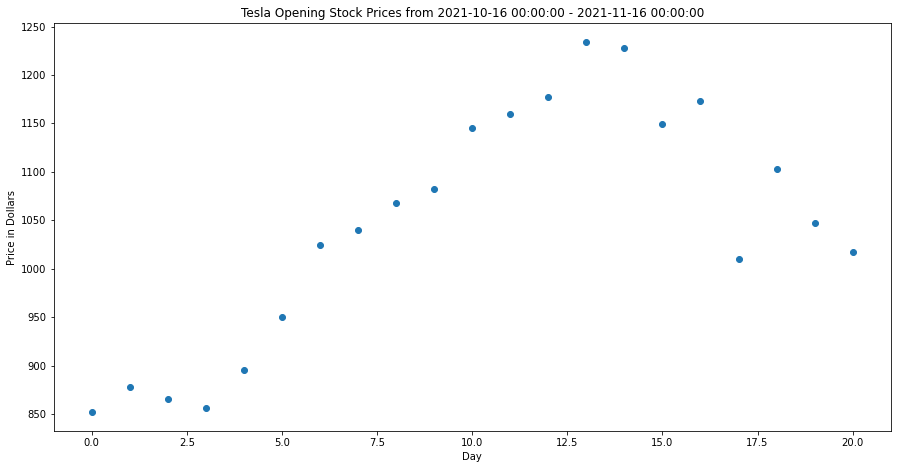

```python
# plot opening prices
plt.figure(figsize = (15, 7.5))
plt.title(f"Tesla Opening Stock Prices from {start_date} - {end_date}")
plt.xlabel('Day')
plt.ylabel('Price in Dollars')
plt.scatter(num_array, prices_df['Open'])
plt.show()
```

#### (b) Implement the stochastic gradient descent algorithm to fit a linear regression model for this data set.

**Update Formulas**

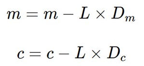

```python
x = num_array
y = np.array(prices_df['Open'])
```

```python
print(x.shape)
print(y.shape)
```

```
(21,)
(21,)
```

```python
# set initial values
m = 1
c = 1
L = 0.001    # learning rate
iterations = 10000
mse_values = []
gradient_m_values = []
gradient_c_values = []
m_values = []
c_values = []
```

```python
# Stochastic Gradient Descent
for iter in range(iterations):
    y_pred = m * x + c
    mse = (1 / num_of_prices) * sum((y - y_pred) ** 2)
    for i in range(num_of_prices):
        if(mse < 0.05):    # stopping condition
            break
        gradient_m = (-2 / num_of_prices) * (x[i] * (y[i] - y_pred[i]))
        gradient_c = (-2 / num_of_prices) * (y[i] - y_pred[i])
        m = m - L * gradient_m
        c = c - L * gradient_c

    # Lists for plotting
    mse_values.append(mse)
    gradient_m_values.append(gradient_m)
    gradient_c_values.append(gradient_c)
    m_values.append(m)
    c_values.append(c)
```

```python
print(mse)
print(gradient_m)
print(gradient_c)
print(m)
print(c)
```

```
7902.440416495774
317.4638335247748
15.873191676238742
13.988114249291888
904.5351538077928
```

```
<function matplotlib.pyplot.show(close=None, block=None)>
```

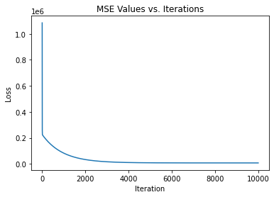

```python
plt.title('MSE Values vs. Iterations')
plt.xlabel('Iteration')
plt.ylabel('Loss')
plt.plot(mse_values)
plt.show
```

We expect the loss (mean squared error) to decrease over time for gradient descent. As seen in the graph above, ours does, which means our gradient descent works as expected.

#### (c) Plot the raw data and your linear regression model together for visual comparison.

```
<function matplotlib.pyplot.show(close=None, block=None)>
```

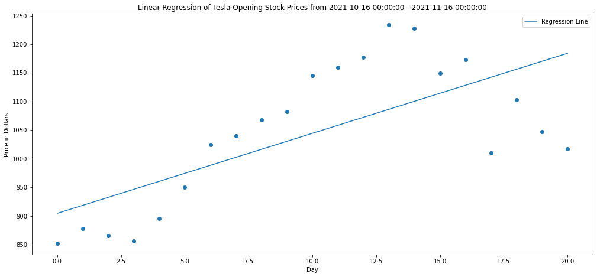

```python
y_pred = m * x + c
plt.figure(figsize = (17, 7.5))
plt.title(f"Linear Regression of Tesla Opening Stock Prices from {start_date} - {end_date}")
plt.xlabel('Day')
plt.ylabel('Price in Dollars')
plt.plot(y_pred, label='Regression Line')
plt.legend()
plt.scatter(x, y)
plt.show
```

#### (d) What does your model predict for Tesla’s stock price for the next three months into the future?

```python
def predict_price(days):
    return m * (days) + c
```

```python
predicted_price = predict_price(num_of_prices + 30)
print(f'The model predicts the price after 1 month to be ${predicted_price:.2f}.')
predicted_price = predict_price(num_of_prices + 60)
print(f'The model predicts the price after 2 months to be ${predicted_price:.2f}.')
predicted_price = predict_price(num_of_prices + 90)
print(f'The model predicts the price after 3 months to be ${predicted_price:.2f}.')
```

```
The model predicts the price after 1 month to be $1617.93.
The model predicts the price after 2 months to be $2037.57.
The model predicts the price after 3 months to be $2457.22.
```

As you can see, the model predicts that the price of Tesla will steadily increase in the coming months. Although this is possible (and it would be great if it was true), it is not very likely given we only used a month's worth of data. Moreover, looking at the graph, the price of Tesla has been in a decline over the past week or so.

#### (e) Explain the pros and cons of gradient descent and stochastic gradient descent.

**Gradient Descent** (aka Batch Gradient Descent) is when all of the data is used for each iteration. The pros of this method are that it is accurate and unbiased. It can also theoretically converge to a global optimum for convex functions and local optimum for other functions. However, since all the data is used for each iteration, if there is a lot of data, it can be very slow. It is also easy for it to get trapped into local modes. A way to solve these issues is with Stochastic Gradient Descent.

**Stochastic Gradient Descent** is when a single sample of the data is used for each update step. This method is faster as a result. It also adds noise to the learning process which can make the model more general. However, the noise can also be a problem, as it can cause the learning to go back and forth. Also, it can be quite slow to converge to a solution.